# DM Project

```r
summary(gainRatioTree)
```

```
Call:
C5.0.formula(formula = Adaptivity.Level ~ ., data = trainData)


C5.0 [Release 2.07 GPL Edition]     Sat Dec  2 23:15:19 2023
-------------------------------

Class specified by attribute `outcome'

Read 1124 cases (14 attributes) from undefined.data

Decision tree:

Class.Duration = 0: Low (109/9)
Class.Duration in {1-3,3-6}:
:...Financial.Condition = Rich:
    :...Age = 1-5: Low (3)
    :   Age in {11-15,16-20,21-25,26-30,6-10}:
    :   :...Internet.Type = Mobile Data:
    :       :...Gender = Girl: High (6)
    :       :   Gender = Boy:
    :       :   :...Age in {11-15,21-25,26-30,6-10}: High (18/6)
    :       :       Age = 16-20: Moderate (4)
    :       Internet.Type = Wifi:
    :       :...IT.Student = Yes:
    :           :...Class.Duration = 1-3: High (56)
    :           :   Class.Duration = 3-6:
    :           :   :...Gender = Boy: Low (3)
    :           :       Gender = Girl: High (12/1)
    :           IT.Student = No:
    :           :...Institution.Type = Government: Moderate (6/1)
    :               Institution.Type = Non Government:
    :               :...Class.Duration = 3-6:
    :                   :...Gender = Boy: High (36)
    :                   :   Gender = Girl: Moderate (2)
    :                   Class.Duration = 1-3:
    :                   :...Gender = Girl: High (33)
    :                       Gender = Boy:
    :                       :...Age in {11-15,16-20,21-25,26-30}: High (4)
    :                           Age = 6-10: Moderate (4)
```

[output cut: 179 more lines]

```
     90.30% Age
     90.30% Financial.Condition
     64.59% Network.Type
     55.52% Gender
     54.98% IT.Student
     47.06% Institution.Type
     34.16% Device
     33.81% Internet.Type
     33.72% Self.Lms
     31.94% Load.shedding
     21.80% Location
      8.63% Education.Level


Time: 0.0 secs
```

```r
confusion_matrix <- confusionMatrix(data = testPred, reference = testData$Adaptivity.Level)

# Calculate precision
precision <- confusion_matrix$table[2,2] / sum(confusion_matrix$table[,2])
cat("\nPrecision:", precision)
```

```
Precision: 0.9255952
```

Model Analysis:

The 70/30 split with Gain Ratio showed good results across the evaluation metrics, with accuracy at 90.84%, precision which is the positive predictive value 92.56%, sensitivity which is the true positive rate at 91.47%, and specificity which is the true negative rate at 95.47%, those are very good numbers and indicate a very good model. The root starts at the Class Duration attribute.

3. Gini Index

```r
GI3.ctree <- ctree(GiniIndexTree, data = trainData)
table(predict(GI3.ctree), trainData$Adaptivity.Level)
```

```
           High Low Moderate
  High      343  25       72
  Low         0 260       83
  Moderate    7  51      283
```

```r
print(GI3.ctree)
```

```
     Conditional inference tree with 35 terminal nodes

Response:  Adaptivity.Level
Inputs:  Gender, Age, Education.Level, Institution.Type, IT.Student, Location, Load.shedding, Financial.Condition, Internet.Type, Network.Type, Class.Duration, Self.Lms, Device
Number of observations:  1124

1) Financial.Condition == {Mid, Poor}; criterion = 1, statistic = 329.996
  2) Class.Duration == {1-3, 3-6}; criterion = 1, statistic = 208.366
    3) Age == {6-10}; criterion = 1, statistic = 157.938
      4)*  weights = 50
    3) Age == {1-5, 11-15, 16-20, 21-25, 26-30}
      5) Gender == {Boy}; criterion = 1, statistic = 83.002
        6) Network.Type == {4G}; criterion = 1, statistic = 72.186
          7) Age == {11-15, 21-25, 26-30}; criterion = 1, statistic = 94.082
            8) Class.Duration == {1-3}; criterion = 1, statistic = 48.443
              9) Self.Lms == {Yes}; criterion = 1, statistic = 42.612
                10)*  weights = 67
              9) Self.Lms == {No}
                11) Load.shedding == {High}; criterion = 1, statistic = 58.177
                  12)*  weights = 8
                11) Load.shedding == {Low}
                  13) IT.Student == {Yes}; criterion = 1, statistic = 35.127
                    14)*  weights = 29
                  13) IT.Student == {No}
                    15) Age == {11-15, 26-30}; criterion = 1, statistic = 25.646
                      16)*  weights = 113
                    15) Age == {21-25}
                      17)*  weights = 9
            8) Class.Duration == {3-6}
              18) IT.Student == {Yes}; criterion = 0.995, statistic = 12.785
                19)*  weights = 20
              18) IT.Student == {No}
                20)*  weights = 23
          7) Age == {1-5, 16-20}
            21) Age == {1-5}; criterion = 0.984, statistic = 10.469
              22)*  weights = 9
            21) Age == {16-20}
              23)*  weights = 49
        6) Network.Type == {2G, 3G}
          24) Self.Lms == {No}; criterion = 1, statistic = 22.963
```

[output cut: 54 more lines]

```
            59) Education.Level == {College}
              61)*  weights = 21
  2) Class.Duration == {0}
    62)*  weights = 107
1) Financial.Condition == {Rich}
  63) Age == {11-15, 21-25, 26-30, 6-10}; criterion = 1, statistic = 87.543
    64) IT.Student == {Yes}; criterion = 0.965, statistic = 18.459
      65) Class.Duration == {3-6}; criterion = 0.995, statistic = 15.602
        66)*  weights = 15
      65) Class.Duration == {1-3}
        67)*  weights = 56
    64) IT.Student == {No}
      68)*  weights = 103
  63) Age == {1-5, 16-20}
    69)*  weights = 15
```

[figure not shown]

```r
plot(GI3.ctree, type="simple")
```

```r
testPred <- predict(GI3.ctree, newdata = testData)
result<-table(testPred, testData$Adaptivity.Level)

results <- confusionMatrix(testPred, testData$Adaptivity.Level)
print(results)
```

```
Confusion Matrix and Statistics

          Reference
Prediction High Low Moderate
  High      343  25       72
  Low         0 260       83
  Moderate    7  51      283

Overall Statistics

               Accuracy : 0.7883
                 95% CI : (0.7632, 0.8118)
    No Information Rate : 0.3897
    P-Value [Acc > NIR] : < 2.2e-16

                  Kappa : 0.6833

 Mcnemar's Test P-Value : < 2.2e-16

Statistics by Class:

                     Class: High Class: Low Class: Moderate
Sensitivity               0.9800     0.7738          0.6461
Specificity               0.8747     0.8947          0.9155
Pos Pred Value            0.7795     0.7580          0.8299
Neg Pred Value            0.9898     0.9027          0.8020
Prevalence                0.3114     0.2989          0.3897
Detection Rate            0.3052     0.2313          0.2518
Detection Prevalence      0.3915     0.3052          0.3034
Balanced Accuracy         0.9273     0.8342          0.7808
```

```r
confusion_matrix <- confusionMatrix(data = testPred, reference = testData$Adaptivity.Level)

# Calculate precision
precision <- confusion_matrix$table[2,2] / sum(confusion_matrix$table[,2])
cat("\nPrecision:", precision)
```

```
Precision: 0.7738095
```

Model Analysis:

This tree shows the exact same results as the Information Gain tree, it shows that the most influential attribute for identifying the Adaptivity Level is the Financial Condition, it suggests that the first split is based on the financial condition being either “Mid” or “Poor.” The subsequent splits are Class Duration being either “1-3” and “3-6”, and then Age. Those results are similar to the 90/10 and 80/20 distributions with IG/GI results.

The 70/30 split with Gini Index, like the one with Information Gain showed average results compared to other trees in all evaluation metrics but precision, with accuracy at 78.83%, precision which is the positive predictive value 77.38%, sensitivity which is the true positive rate at 80%, and specificity which is the true negative rate at 89.51%, those are good numbers and indicate that the model is good.

### 5.2 Clustering:

Clustering is a machine learning technique that involves grouping similar data points together based on inherent patterns and similarities. In this project, we leverage clustering to unveil hidden structures within our dataset, identifying natural groupings of students’ attributes that can assist in understanding the intrinsic relationships between them. By employing clustering, we aim to reveal patterns that may not be immediately apparent in identifying students’ adaptability level in online education.

We will start by removing our class label, then trying different methods to finding the optimal number of clusters, pick 3 numbers of K, which represent the number of clusters, and then finally validate our clusters based on their results on different metrics, namely the **Average Silhouette Width**, which measures how similar an object is to its own cluster compared to other clusters, the **Total Within-Cluster Sum of Square**, which quantifies the compactness of clusters, **BCubed Precision** and **BCubed Recall**, which are used to evaluate clustering performance, BCubed Precision measures the proportion of correctly clustered instances within a cluster, while BCubed Recall measures the proportion of correctly clustered instances for a given true class.

The results and findings will be presented afterwards in the Findings section.

#### 5.2.1 Removing the class label:

```r
# load the dataset
df <- balancedDataset

#drop the class label (Adaptivity Level))
df<-df[1:13]
str(df)
```

```
tibble [1,605 × 13] (S3: tbl_df/tbl/data.frame)
 $ Gender             : Factor w/ 2 levels "Boy","Girl": 1 2 2 2 2 1 1 1 1 1 ...
 $ Age                : Factor w/ 6 levels "1-5","11-15",..: 4 4 3 2 3 2 2 2 3 2 ...
 $ Education.Level    : Factor w/ 3 levels "College","School",..: 3 3 1 2 2 2 2 2 1 2 ...
 $ Institution.Type   : Factor w/ 2 levels "Government","Non Government": 2 2 1 2 2 2 2 2 1 2 ...
 $ IT.Student         : Factor w/ 2 levels "No","Yes": 1 1 1 1 1 1 1 1 1 1 ...
 $ Location           : Factor w/ 2 levels "No","Yes": 2 2 2 2 2 2 2 2 2 2 ...
 $ Load.shedding      : Factor w/ 2 levels "High","Low": 2 1 2 2 2 2 2 2 2 2 ...
 $ Financial.Condition: Factor w/ 3 levels "Mid","Poor","Rich": 1 1 1 1 2 2 1 1 1 1 ...
 $ Internet.Type      : Factor w/ 2 levels "Mobile Data",..: 2 1 2 1 1 1 2 2 2 1 ...
 $ Network.Type       : Factor w/ 3 levels "2G","3G","4G": 3 3 3 3 2 2 3 3 3 2 ...
 $ Class.Duration     : Factor w/ 3 levels "0","1-3","3-6": 3 2 2 2 1 2 1 2 2 2 ...
 $ Self.Lms           : Factor w/ 2 levels "No","Yes": 1 2 1 1 1 1 1 1 1 1 ...
 $ Device             : Factor w/ 3 levels "Computer","Mobile",..: 3 2 2 2 2 2 2 2 2 2 ...
```

```r
distinct_data_points <- nrow(unique(df))
print(distinct_data_points)
```

```
[1] 236
```

#### 5.2.2 Finding the optimal number of clusters:

1- Using the Silhouette Method:

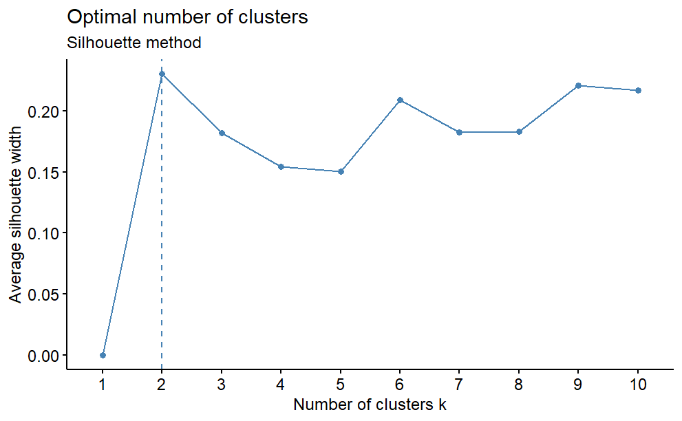

```r
# Convert dataframe columns to numeric
df_numeric <- as.data.frame(lapply(df, as.numeric))

df <- scale(df_numeric)
fviz_nbclust(df, kmeans, method = "silhouette") + labs(subtitle = "Silhouette method")
```

Graph description: K=2 seems to be the optimal number of clusters using the silhouette method.

2- Using the Elbow Method:

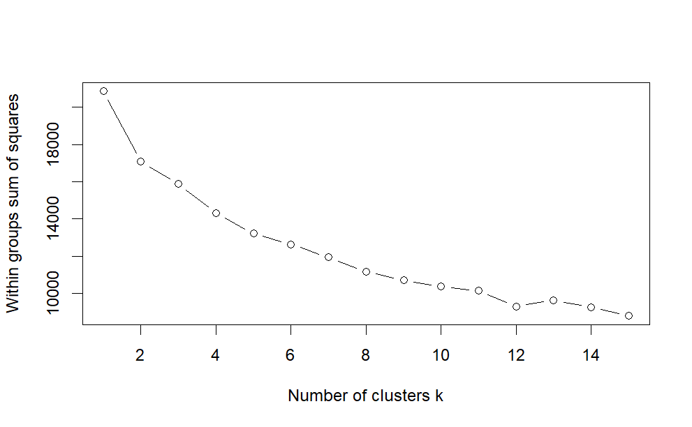

```r
wssplot<- function (df, nc=15, seed=1234)
{
  wss<-(nrow(df)-1)*sum(apply(df,2,var))
  for(i in 2:nc){
    set.seed(seed)
    wss[i] <- sum(kmeans(df, centers = i)$withinss)}
  plot(1:nc,wss, type="b", xlab="Number of clusters k", ylab="Within groups sum of squares")
}
df1 = na.omit(df)
wssplot(df1)
```

Graph description: Using the elbow method, K=2 also seems to be the optimal number of clusters.

As you can see, we employed two methods, the Silhouette method and the Elbow method, to assist in determining the optimal number of clusters for our dataset. Interestingly, both the Silhouette method and the Elbow method pointed towards 2 clusters as a potentially optimal choice. The Silhouette method, which measures how well-defined and separated the clusters are, suggested 2 as the most suitable number, while the Elbow method, examining the within-cluster sum of squares, repeated this recommendation. However, to ensure a comprehensive exploration, we also considered k values of 5 and 4 as they also seem good according to the elbow method. The inclusion of these additional cluster counts allows us to assess whether the clustering structure remains stable across different configurations.

#### 5.2.3 Performing K-Means Clustering with K=5, K=4, K=2:

```r
# Make this example reproducible
set.seed(1234)

# Determine the maximum value of k you want to try
max_k <- 5

# Create an empty list to store the results
kmeans_results <- list()

# Loop through different k values
for (k in 1:max_k) {
  set.seed(1234)  # Set seed inside the loop for reproducibility
  kmeans_results[[k]] <- kmeans(df_numeric, centers = k, nstart = 25)
}
```

1. K = 5

```r
k5_results <- kmeans_results[[5]]
k5_results
```

[output not shown]

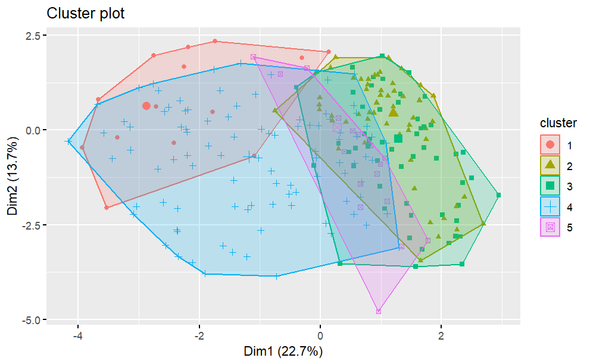

```r
# Visualize the clustering
fviz_cluster(k5_results, data = df_numeric, geom = "point")
```

```r
# Calculate the silhouette width
silhouette_score <- silhouette(k5_results$cluster, dist(df_numeric))
# Extract the average silhouette width
average_silhouette <- mean(silhouette_score[, 3])

within_cluster_sum_squares <- k5_results$tot.withinss

# BCubed function
clusters <- k4_results$cluster
ground_truth <- c(balancedDataset$Adaptivity.Level)

BCubed_Precision <- function(clusters, ground_truth) {
  n <- length(clusters)
  precision <- 0
  for (i in 1:n) {
    same_cluster <- clusters == clusters[i]
    same_ground_truth <- ground_truth == ground_truth[i]
    precision <- precision + sum(same_cluster & same_ground_truth) / sum(same_cluster)
  }
  precision <- precision / n
  return(precision)
}

BCubed_Recall <- function(clusters, ground_truth) {
  n <- length(clusters)
  recall <- 0
  for (i in 1:n) {
    same_cluster <- clusters == clusters[i]
    same_ground_truth <- ground_truth == ground_truth[i]
    recall <- recall + sum(same_cluster & same_ground_truth) / sum(same_ground_truth)
  }
  recall <- recall / n
  return(recall)
}

precision <- BCubed_Precision(clusters, ground_truth)
recall <- BCubed_Recall(clusters, ground_truth)


# Display the results
cat("Average Silhouette width:", average_silhouette, "\n")
```

```
Average Silhouette width: 0.255273
```

```r
cat("Total within-cluster sum of squares:", within_cluster_sum_squares, "\n")
```

```
Total within-cluster sum of squares: 3549.907
```

```r
cat("BCubed precision:", precision, "\n")
```

```
BCubed precision: 0.3906725
```

```r
cat("BCubed recall:", recall, "\n")
```

```
BCubed recall: 0.3172995
```

2. K = 4

```r
k4_results <- kmeans_results[[4]]
k4_results
```

[output not shown]